# 股價評估:ROE Valuation

周育呈 e11559560532@gmail.com

2024-10-02

# 1. 前言

ROE Valuation 是碩一$\color{red}{資產管理}$盈課老師的上課內容，大學的財管幾乎都會上 DDM(Dividend Discount Model 股利折現模型) 跟 GGM(Gordon Growth Model 戈登成長模型) 還有 DCF (Discount Cash flow 自由現金流量折現模型)，DCF 在碩一另外一節課財務管理的小組報告有實際算過，但自由現金流量的計算牽扯到 CAPEX(資本支出)，所以在預估未來的自由現金流量可能會不穩定，導致結論與實際股價可能相去甚遠而參考價值低(我們當時的狀況)， DCF 是基於公司現金流估算的股票內涵價值，計算過程沒有牽扯到歷史股利或股價，而 ROE Valuation 是基於 GGM 的概念加上 P/E ratio(本益比) 評價法的評價模型，模型不是估算股票內涵價值，而是根據模型假設直接估算未來股價，ROE Valuation 的靈活度較上述模型高，故特別把計算流程用R語言實現出來和寫這篇 RMarkdown 記錄下來，ROE Valuation 詳細的計算方式與優缺點在後續小節說明。

# 2. 模型說明

ROE 評價法與其他評價法一樣，適合業務已成熟的公司，畢竟模型需要預測公司未來表現，故公司財報或股利政策越穩健模型的結論則越可靠。

## 2.1 模型假設

共需要 5 筆資料：  
1. 最近一期的每股淨值 (Book value per share, BPS)：已知  
2. 未來的股利政策 (Dividend payout ratio, DPR)：$\color{red}{需假設}$  
3. 未來的股東權益報酬率 (Return on equity, ROE)：$\color{red}{需假設}$  
4. 未來的本益比 (Price to earning ratio, P/E ratio)：$\color{red}{需假設}$  
5. 要求報酬率 (Required rate of return, R)：$\color{red}{需假設}$

## 2.2 評價步驟

以我現在的時間 2024 年 9 月 11 為例日，範例公司以玉山金(2884)簡單計算，模型假設數值皆取歷史平均數並往後預測 3 年，即 2025、2026 與 2027 年。
資料來源：[財報狗：玉山金(2884)](https://statementdog.com/analysis/2884/)。(畢業了沒有 TEJ用，好懷念 TEJ…)
1. 第一步：預估本期末BPS
根據財報狗的玉山金 2023 年的 BPS 為 15.08，
玉山金近 3 年的 ROE 為 10.95%、8.06%、10.03%，取平均值 9.68%為今年2024與未來 3 年的 ROE，
玉山金近 3 年的 DPR 為 43.51%、17.27%、85.11%，取平均值 48.63%為今年2024與未來 3 年的 DPR。
玉山金近 3 個月的 P/E ratio 為 20.57、20.76、18.08，取平均值 19.80333 為未來的 P/E ratio。
以 2023 年 BPS 乘以 ROE 預估今年 2024 玉山金的每股盈餘(EPS)：
$$\rm{EPS_{2024}} = BPS_{2023}\; \times \;ROE
= 15.08 \; \times \;0.0968=1.459744$$
有了今年 2024 的 EPS 後乘上 DPR 得到 2024 的現金股利(Div)：
$$\rm{Div_{2024}}=EPS_{2024}\; \times \; DPR
= 1.459744 \; \times \; 0.4863 = 0.7098735$$
2024的 EPS 減去 2024 的 Div 後得到 2024 的增加保留盈餘(AtRE)：
$$\rm{AtRE_{2024}}= EPS_{2024} \; -
\;Div_{2024} = 1.459744\;-\;0.7098735=0.7498705$$
再以 2023 年 BPS 加上 2024 的 AtRE 後得到 2024 年 BPS：
$$\rm{BPS_{2024}}=BPS_{2023} \;+\;AtRE_{2024}=
15.08\;+\;0.7498705=15.82987$$
2. 第二步：預估未來現金股利與股價
依照第一步的步驟計算出 2025、2026 和 2027 年的現金股利與 2027 年的 EPS，這裡就不把上述的計算過程列出來，未來 3 年 Div 分別是 0.7451728、0.7822274、0.8211245，再透過最後一年 2027 的 EPS 與 P/E ration 預估 2027 年的玉山金股價：
$$\rm{Price_{2027}}=EPS_{2027}\;\times\;PE \;ration
= 1.688514\;\times\;19.80333=33.4382$$
3. 第三部：折現所有現金流
最後一步理所當然就是現金流折現了，以 5% 要求報酬率(R)折現：
$$\rm \frac{Div_{2025}}{(1+R)^{1}}+\frac{Div_{2026}}{(1+R)^{2}}+\frac{Div_{2027}+Price_{2027}}{(1+R)^{3}}=
\frac{0.7451728}{1.05}+\frac{0.7822274}{1.05^{2}}+\frac{0.8211245+33.4382}{1.05^{3}}=31.01368$$
從上述的評價步驟可看到計算過程的第 1 期是預估本期 BPS，而從折現方程式可看到 2025 的 Div 有折現 1 期，故 ROE 評價法所預估出的股價時間點為本期末(即下期初)，以上述玉山金的例子預估的股價時間點為 2025 年初 2024 年末，即預估股價中不包含本期 2024 年的 Div。

# 3. ROE_valuation()

這小節說明我的function：$\rm ROE\_valuation()$ 的參數(Arguments)和輸出(Outputs)，$\rm ROE\_valuation()$ 的計算邏輯即上述 2.2 評價步驟。  
$\rm ROE\_valuation()$ 的程式碼我放在這個[Rmarkdown檔案](https://tarocity.github.io/ROE_code.html)

```r
ROE_valuation <- function(
                          N_period = 3,
                          arg_BPS = NA,
                          arg_ROE = NA,
                          arg_DPR = NA,
                          Required_rate = c(0.06,0.07,0.08,0.09,0.1),
                          PE_ratio = c(8,10,12,14,16,18),
                          N_price = NA,
                          Freq = c("annual", "semiannual", "quarterly"),
                          Dividend_Tax = 0,
                          Stock_Price = NA,
                          show.assumption = TRUE,
                          asset.name = NULL){......}
```

## 3.1 參數(Arguments)

1. N_period：  
   模型估計的期數，需輸入大於等於 2 的正整數。
2. arg_BPS：  
   模型的起始 BPS。
3. arg_ROE：  
   模型每期使用的 ROE，輸入的 ROE 筆數需小於等於 N_period。  
   以 N_period = 5 為例：
- 如總共輸入 5 筆 arg_ROE 數值，則模型依序使用這 5 筆 ROE 做計算。
- 如只輸入 1 筆 arg_ROE = 0.1，則模型 5 期皆使用 ROE = 0.1 做計算。
- 如只輸入 3 筆 arg_ROE = c(0.1, 0.2, 0.025)，則模型前 3 期依序以輸入的 ROE 做計算，剩下2期則使用 arg_ROE 的最後一筆數值做計算，即第 4 第 5 期的 ROE 同為 0.025。
4. arg_DPR：  
   模型每期使用的 DPR，輸入的 DPR 筆數需小於 N_period，輸入筆數的計算邏輯同 arg_ROE。
5. Required_rate：  
   模型的要求報酬率，用以最後一步的現金流折現，可輸入多筆數值，模型會以不同折現率輸出不同的預估股價。
6. PE_ratio：  
   模型計算最後一期股價所使用的 P/E ratio，可輸入多筆數值，模型會以不同 P/E ratio 輸出不同的預估股價。
7. N_price：  
   考慮到公司有時候是淨損的，即 EPS 為負數導致無法使用 P/E ratio 預估股價， 此時可改以其他價格乘數(Price Multiples) 預估最後一期股價，如：P/B、P/S、P/FCF 與 P/EBITDA 等等。  
   N_price 為模型最後一期的預估股價，Default 為 NA，如有輸入數值則模型最後一期的股價則以輸入的 N_price 計算，此時不論 PE_ratio 是否有輸入數值模型皆以 N_price 作為最後一期股價。
8. Freq：  
   模型估計的頻率，分為年、半年、季，需輸入 “annual”、“semiannual”、“quarterly” 其一。  
   以 Freq = “semiannual” 為例，模型的每期 Div 為半年的 Div，假如折現率輸入 Required_rate = 0.1，則模型最後會以 0.05 折現現金流，即 0.1/2 = 0.05，如 Freq = “quarterly” 則以 0.1/4 = 0.025 折現， 故 Required_rate 一律以$\color{red}{年利率}$輸入。
9. Dividend_Tax：  
   模型 Div 的稅率，如考慮現金股利課稅可輸入稅率，如 Dividend_Tax = 0.2，則最終每筆 $\rm Div \times (1-0.2)$ 再去做折現。
10. Stock_Price：
    Default 為 NA，可輸入當下的股價，模型會依據所輸入股價與預估股價去計算內部報酬率(IRR)，以上述玉山金為例模型依照下方方程式求解 IRR：
    $$\rm 0=\frac{0.7451728}{IRR}+\frac{0.7822274}{IRR^{2}}+\frac{0.8211245+33.4382}{IRR^{3}}-StockˍPrice$$
    如有輸入 Stock_Price，模型回傳根據輸入的 Stock_Price 求解方程式的 IRR。
    如沒輸入 Stock_Price 模型則不會回傳 IRR。
11. show.assumption：  
    輸入 show.assumption = TRUE 則函數會在 Console 顯示所輸入的模型假設，詳情見下方 3.2 輸出(Outputs) 。
12. asset.name：  
    輸入模型估計的資產名稱，會在 Console 中顯示資產名稱，詳情見下方 3.2 輸出(Outputs)。

## 3.2 輸出(Outputs)

$\rm ROE\_valuation()$ 會回傳一個 list，裡面包含一個 $\rm list(model.assumption)$ 存有模型假設，和一個 $\rm data.frame(model.result)$ 存有模型的結論並四捨五入到小數點第 2 位，model.result 裡的 columns 包含：

1. PEration：每個 row 為一筆 PE_ratio 所預估的結論。
2. N_price：股票在最後一期依照 PE_ratio 所預估出的股價或直接輸入的股價。
3. TIV：總投資價值，即不折現直接加總所有現金流的數值。
4. Dsc %：模型不同 Required_rate 所預估出的股價。
5. IRR(%)：如有輸入 Stock_Price，則多一個 column 顯示依照輸入的股價所計算出的 IRR。

下面根據上述的玉山金(2884)的例子輸入模型假設：  
1. 不輸入 Stock_Price 和 asset.name

```r
E.SUN <- ROE_valuation(N_period = 4,
                       arg_BPS = 15.08,
                       arg_ROE = 0.0968,
                       arg_DPR = 0.4863,
                       Required_rate = c(0.05, 0.06, 0.07, 0.08, 0.09, 0.1),
                       PE_ratio = c(8, 10, 12, 14, 16, 18, 19.80333),
                       Freq = c("annual"),
                       Dividend_Tax = 0,
                       Stock_Price = NA,
                       show.assumption = TRUE
)
```

```
##  -----------ROE valuation-----------
##  Estimate for 4 Years
##  Basic Assumption :
##  Dividend Payout Ratio = 48.63 % (for all periods)
##  ROE = 9.68 % (for all periods)
##  Dividend Taxes = 0 (%)
##  Required rate of Return = 5 ~ 10 (%)
##  P/E ratio = 8 ~ 19.80333
##  Current Price = NA
##  -----------------------------------
##  Please check the Estimated Price in the model.result
```

$\rm model.assumption$ 裡包含以下的模型假設：

```r
E.SUN$model.assumption
```

```
## $Asset
## NULL
##
## $frequency
## [1] "Years"
##
## $period.number
## [1] 4
##
## $BPS
## [1] 15.08
##
## $ROE
## [1] 0.0968 0.0968 0.0968 0.0968
##
## $DPR
## [1] 0.4863 0.4863 0.4863 0.4863
##
## $dividend.tax
## [1] 0
##
## $PEratio
## [1]  8.00000 10.00000 12.00000 14.00000 16.00000 18.00000 19.80333
##
## $N_price
## [1] NA
##
## $required.rate
## [1] 0.05 0.06 0.07 0.08 0.09 0.10
##
## $current.price
## [1] NA
```

$\rm model.result$ 則為下方的 data.frame：

| PEratio | N_price | TIV | Dsc 5% | Dsc 6% | Dsc 7% | Dsc 8% | Dsc 9% | Dsc 10% |
| --- | --- | --- | --- | --- | --- | --- | --- | --- |
| 8.0 | 13.51 | 27.60 | 13.8 | 13.43 | 13.08 | 12.74 | 12.41 | 12.09 |
| 10.0 | 16.89 | 30.98 | 16.71 | 16.27 | 15.83 | 15.42 | 15.01 | 14.63 |
| 12.0 | 20.26 | 34.35 | 19.63 | 19.10 | 18.59 | 18.10 | 17.62 | 17.16 |
| 14.0 | 23.64 | 37.73 | 22.55 | 21.94 | 21.35 | 20.78 | 20.23 | 19.70 |
| 16.0 | 27.02 | 41.11 | 25.47 | 24.77 | 24.10 | 23.46 | 22.84 | 22.24 |
| 18.0 | 30.39 | 44.48 | 28.38 | 27.61 | 26.86 | 26.14 | 25.45 | 24.78 |
| 19.8 | 33.44 | 47.53 | 31.01 | 30.16 | 29.35 | 28.56 | 27.80 | 27.06 |

PE_ratio 共輸入了 7 筆數值，故 model.result 共有 7 個 row，可看到預估股價同上述玉山金的結論為 31.01。  
2. 輸入 Stock_Price 和 asset.name  
如 Stock_Price 依照今天 09-18 玉山金的收盤價 27.85 輸入， asset.name 也輸入「玉山金 (2884)」。

```r
E.SUN <- ROE_valuation(N_period = 4,
                       arg_BPS = 15.08,
                       arg_ROE = 0.0968,
                       arg_DPR = 0.4863,
                       Required_rate = c(0.05, 0.06, 0.07, 0.08, 0.09, 0.1),
                       PE_ratio = c(8, 10, 12, 14, 16, 18, 19.80333),
                       Freq = c("annual"),
                       Dividend_Tax = 0,
                       Stock_Price = 27.85,
                       show.assumption = TRUE,
                       asset.name = "玉山金(2884)"
)
```

```
##  -----------ROE valuation-----------
##  Estimate 玉山金(2884) for 4 Years
##  Basic Assumption :
##  Dividend Payout Ratio = 48.63 % (for all periods)
##  ROE = 9.68 % (for all periods)
##  Dividend Taxes = 0 (%)
##  Required rate of Return = 5 ~ 10 (%)
##  P/E ratio = 8 ~ 19.80333
##  Current Price = 27.85
##  -----------------------------------
##  Please check the Estimated Price in the model.result
```

| PEratio | N_price | TIV | Dsc 5% | Dsc 6% | Dsc 7% | Dsc 8% | Dsc 9% | Dsc 10% | IRR(%) |
| --- | --- | --- | --- | --- | --- | --- | --- | --- | --- |
| 8.0 | 13.51 | 27.60 | 13.8 | 13.43 | 13.08 | 12.74 | 12.41 | 12.09 | -17.79 |
| 10.0 | 16.89 | 30.98 | 16.71 | 16.27 | 15.83 | 15.42 | 15.01 | 14.63 | -12.01 |
| 12.0 | 20.26 | 34.35 | 19.63 | 19.10 | 18.59 | 18.10 | 17.62 | 17.16 | -6.92 |
| 14.0 | 23.64 | 37.73 | 22.55 | 21.94 | 21.35 | 20.78 | 20.23 | 19.70 | -2.35 |
| 16.0 | 27.02 | 41.11 | 25.47 | 24.77 | 24.10 | 23.46 | 22.84 | 22.24 | 1.83 |
| 18.0 | 30.39 | 44.48 | 28.38 | 27.61 | 26.86 | 26.14 | 25.45 | 24.78 | 5.68 |
| 19.8 | 33.44 | 47.53 | 31.01 | 30.16 | 29.35 | 28.56 | 27.80 | 27.06 | 8.93 |

可看到函數回傳的 model.result 最後面多了一個 IRR(%) 的 column， 依照上述假設，如 2027 年時 P/E ratio 為 19.80 則現在以 27.85 元買入的隱含 IRR 為 8.93%。  
3. 輸入 N_price = E.SUN$N_price  
直接輸入最後一期股價不使用 PE_ratio 預估，這裡輸入的股價以前面 E.SUN 的 N_period 直接當作模型最後一期股價。

```r
E.SUN_NP <- ROE_valuation(N_period = 4,
                          arg_BPS = 15.08,
                          arg_ROE = 0.0968,
                          arg_DPR = 0.4863,
                          Required_rate = c(0.05, 0.06, 0.07, 0.08, 0.09, 0.1),
                          PE_ratio = c(8, 10, 12, 14, 16, 18, 19.80333),
                          N_price = E.SUN$model.result$N_price,
                          Freq = c("annual"),
                          Dividend_Tax = 0,
                          Stock_Price = 27.85,
                          show.assumption = TRUE,
                          asset.name = "玉山金(2884)"
)
```

```
##  -----------ROE valuation-----------
##  Estimate 玉山金(2884) for 4 Years
##  Basic Assumption :
##  Dividend Payout Ratio = 48.63 % (for all periods)
##  ROE = 9.68 % (for all periods)
##  Dividend Taxes = 0 (%)
##  Required rate of Return = 5 ~ 10 (%)
##  N_price = 13.51 ~ 33.44
##  Current Price = 27.85
##  -----------------------------------
##  Please check the Estimated Price in the model.result
```

| PEratio | N_price | TIV | Dsc 5% | Dsc 6% | Dsc 7% | Dsc 8% | Dsc 9% | Dsc 10% | IRR(%) |
| --- | --- | --- | --- | --- | --- | --- | --- | --- | --- |
| NA | 13.51 | 27.60 | 13.8 | 13.43 | 13.08 | 12.74 | 12.41 | 12.09 | -17.78 |
| NA | 16.89 | 30.98 | 16.72 | 16.27 | 15.84 | 15.42 | 15.02 | 14.63 | -12 |
| NA | 20.26 | 34.35 | 19.63 | 19.1 | 18.59 | 18.10 | 17.62 | 17.16 | -6.93 |
| NA | 23.64 | 37.73 | 22.55 | 21.94 | 21.35 | 20.78 | 20.23 | 19.7 | -2.35 |
| NA | 27.02 | 41.11 | 25.47 | 24.78 | 24.11 | 23.46 | 22.84 | 22.24 | 1.83 |
| NA | 30.39 | 44.48 | 28.38 | 27.6 | 26.86 | 26.14 | 25.44 | 24.77 | 5.68 |
| NA | 33.44 | 47.53 | 31.02 | 30.17 | 29.35 | 28.56 | 27.8 | 27.06 | 8.93 |

可看到第 1 個 column 的 PEratio 全變成 NA，且 console 顯示的模型假設也從 P/E ratio = 8 ~ 19.80333 變為 N_price = 13.51 ~ 33.44，而由於 E.SUN_NP 所輸入的 N_price 是四捨五入過的，所以 E.SUN 與 E.SUN_NP 有些數值因為浮點運算差了 0.01，即我紅色標出來的數字。  
4. 直接輸入 N_price、Dividend_Tax 與變動的 ROE、DPR

```r
E.SUN_NP <- ROE_valuation(N_period = 4,
                          arg_BPS = 15.08,
                          arg_ROE = c(0.0968, 0.1, 0.11),
                          arg_DPR = c(0.4863, 0.5, 0.55),
                          Required_rate = c(0.05, 0.06, 0.07, 0.08, 0.09, 0.1),
                          PE_ratio = c(8, 10, 12, 14, 16, 18, 19.80333),
                          N_price = c(31, 32, 33, 33.44),
                          Freq = c("annual"),
                          Dividend_Tax = 0.1,
                          Stock_Price = 27.85,
                          show.assumption = TRUE,
                          asset.name = "玉山金(2884)"
)
```

```
##  -----------ROE valuation-----------
##  Estimate 玉山金(2884) for 4 Years
##  Basic Assumption :
##  Dividend Payout Ratio = 48.63 | 50 | 55 | 55 (%)
##  ROE = 9.68 | 10 | 11 | 11 (%)
##  Dividend Taxes = 10 (%)
##  Required rate of Return = 5 ~ 10 (%)
##  N_price = 31 ~ 33.44
##  Current Price = 27.85
##  -----------------------------------
##  Please check the Estimated Price in the model.result
```

| PEratio | N_price | TIV | Dsc 5% | Dsc 6% | Dsc 7% | Dsc 8% | Dsc 9% | Dsc 10% | IRR(%) |
| --- | --- | --- | --- | --- | --- | --- | --- | --- | --- |
| NA | 31 | 46.40 | 29.10 | 28.30 | 27.54 | 26.80 | 26.09 | 25.40 | 6.59 |
| NA | 32 | 47.40 | 29.96 | 29.14 | 28.35 | 27.59 | 26.86 | 26.15 | 7.66 |
| NA | 33 | 48.40 | 30.83 | 29.98 | 29.17 | 28.39 | 27.63 | 26.90 | 8.71 |
| NA | 33.44 | 48.84 | 31.21 | 30.35 | 29.53 | 28.74 | 27.97 | 27.23 | 9.16 |

如果模型每期的 ROE 與 DPR 不一樣會在 Console 全部顯示出來，而另外透過其他價格乘數預估最後一期股價，皆需另外計算完後直接輸入 N_price ，可看到雖然 PE_ratio 輸入了 7 筆數值，但最終回傳的 E.SUN_NP 只使用了輸入的 4 筆 N_price 去做計算。

# 4. 模型優缺點和注意事項

這小節討論一下 $\rm ROE\_valuation()$ 的優缺點與使用的注意事項。

## 4.1 優點

1. 不需永久假設：  
   不論是 GGM 或是 DCF，模型都假設公司以一個固定的成長率永久成長下去，因此需要計算公司的終值 (Terminal Value)。
2. 模型靈活度：  
   ROE 評價法無需假設公司以固定的成長率永久存在，可依照對公司的了解自行決定需往後預估幾期，基於這點我讓 $\rm ROE\_valuation()$ 可依照年、半年、季的頻率去預估股價，讓模型的靈活度更高。

## 4.2 缺點

1. 依賴 P/E ratio：  
   從上述的 2.2 評價步驟 可看到，如果模型預估期數很少，則 ROE 評價法的現金流很大一部份來自最後一期透過 P/E ratio 預估出的股價， 故選一個適合 P/E ratio 對於預估結果至關重要，因此 $\rm ROE\_valuation()$ 可一次預估多個 P/E ratio 的結果，讓模型的預估過程更方便。  
   題外話，碩一時老師實際操作是以該公司過去 P/E ratio 的高點與低點決定 P/E ratio 的區間，再依照保守或激進去決定最終要使用的 P/E ratio 大小。
2. 固定假設：  
   我上述 2.2 評價步驟 與老師上課講解的 PPT 一樣，每期皆以固定的 ROE 與 DPR 去計算當期數值， 因此我讓 $\rm ROE\_valuation()$ 每期可以使用不一樣的 ROE 與 DP 去預估股價，不需要採取固定假設。
3. 不考慮公司內涵價值：  
   從 2.2 評價步驟 可看到，模型的所預估的股價只以公司現金股利與未來股價計算出來的，不考慮公司實際的營運狀況與現金流，故預估的股價不是公司內涵價值，雖說內涵價值也可能長期偏離市場價值就是了。

## 4.3 注意事項

1. ROE 數值：  
   由於 $\rm ROE\_valuation()$ 可以調整模型頻率，故 ROE 輸入的數值需與模型頻率一致，同樣以財報狗的玉山金為例，模型假設不變只調整估計的頻率：

```r
E.SUN_quarter <- ROE_valuation(N_period = 4,
                               arg_BPS = 15.08,
                               arg_ROE = 0.0968,
                               arg_DPR = 0.4863,
                               Required_rate = c(0.05, 0.06, 0.07, 0.08, 0.09, 0.1),
                               PE_ratio = c(8, 10, 12, 14, 16, 18, 19.80333),
                               Freq = c("quarter"), # 與3.2.2相比只有這裡更動
                               Dividend_Tax = 0,
                               Stock_Price = 27.85,
                               show.assumption = TRUE,
                               asset.name = "玉山金(2884)"
)
```

```
##  -----------ROE valuation-----------
##  Estimate 玉山金(2884) for 4 Quarters
##  Basic Assumption :
##  Dividend Payout Ratio = 48.63 % (for all periods)
##  ROE = 9.68 % (for all periods)
##  Dividend Taxes = 0 (%)
##  Required rate of Return = 5 ~ 10 (%)
##  P/E ratio = 8 ~ 19.80333
##  Current Price = 27.85
##  -----------------------------------
##  Please check the Estimated Price in the model.result
```

| PEratio | N_price | TIV | Dsc 5% | Dsc 6% | Dsc 7% | Dsc 8% | Dsc 9% | Dsc 10% | IRR(%) |
| --- | --- | --- | --- | --- | --- | --- | --- | --- | --- |
| 8.0 | 54.03 | 68.12 | 54.35 | 53.95 | 53.56 | 53.17 | 52.79 | 52.41 | 108.00 |
| 10.0 | 67.54 | 81.63 | 67.36 | 66.87 | 66.38 | 65.90 | 65.42 | 64.95 | 145.97 |
| 12.0 | 81.05 | 95.14 | 80.37 | 79.79 | 79.21 | 78.63 | 78.06 | 77.50 | 179.23 |
| 14.0 | 94.56 | 108.65 | 93.39 | 92.70 | 92.03 | 91.36 | 90.70 | 90.04 | 209.02 |
| 16.0 | 108.06 | 122.16 | 106.40 | 105.62 | 104.85 | 104.09 | 103.33 | 102.58 | 236.13 |
| 18.0 | 121.57 | 135.66 | 119.42 | 118.54 | 117.67 | 116.82 | 115.97 | 115.13 | 261.08 |
| 19.8 | 133.75 | 147.84 | 131.15 | 130.19 | 129.24 | 128.29 | 127.36 | 126.44 | 282.06 |

如果只把模型估計的頻率改為$\color{red}{季}$其他條件不變則所有預估股價都大幅提高，原因其實是原假設是使用$\color{red}{年}$ ROE 沒有改為$\color{red}{季}$ ROE， 且 $\rm ROE\_valuation()$透過 P/E ratio 乘上 EPS 計算 N_price 時會再乘上一個頻率調整權重：freq_adj，如果 Freq = “annual” 則 freq_adj = 1，而 Freq = “quarterly” 則 freq_adj = 4，因此 E.SUN_quarter 的 N_price 變為使用$\color{red}{年}$ ROE 計算出$\color{red}{年}$ EPS，$\color{red}{年}$ EPS 乘上 P/E ratio 再乘上 freq_adj = 4，導致所有的預估股價都大幅提高。  
根據[財報狗：玉山金 ROE](https://statementdog.com/analysis/2884/roe-roa) 可看到最新的季 ROE 為 2.52%、2.59%、2.68%，大約是原假設的 10.95%、8.06%、10.03% 的四分之一，因此在把 arg_ROE 除以 4 然後估計一次：

```r
E.SUN_quarterly <- ROE_valuation(N_period = 4,
                                 arg_BPS = 15.08,
                                 arg_ROE = 0.0968 / 4, # 年ROE除以4
                                 arg_DPR = 0.4863,
                                 Required_rate = c(0.05, 0.06, 0.07, 0.08, 0.09, 0.1),
                                 PE_ratio = c(8, 10, 12, 14, 16, 18, 19.80333),
                                 Freq = c("quarter"), # 與3.2.2相比只有這裡更動
                                 Dividend_Tax = 0,
                                 Stock_Price = 27.85,
                                 show.assumption = TRUE,
                                 asset.name = "玉山金(2884)"
)
```

```
##  -----------ROE valuation-----------
##  Estimate 玉山金(2884) for 4 Quarters
##  Basic Assumption :
##  Dividend Payout Ratio = 48.63 % (for all periods)
##  ROE = 2.42 % (for all periods)
##  Dividend Taxes = 0 (%)
##  Required rate of Return = 5 ~ 10 (%)
##  P/E ratio = 8 ~ 19.80333
##  Current Price = 27.85
##  -----------------------------------
##  Please check the Estimated Price in the model.result
```

| PEratio | N_price | TIV | Dsc 5% | Dsc 6% | Dsc 7% | Dsc 8% | Dsc 9% | Dsc 10% | IRR(%) |
| --- | --- | --- | --- | --- | --- | --- | --- | --- | --- |
| 8.0 | 12.12 | 15.39 | 12.21 | 12.12 | 12.03 | 11.94 | 11.86 | 11.77 | -93.35 |
| 10.0 | 15.15 | 18.42 | 15.13 | 15.02 | 14.91 | 14.80 | 14.69 | 14.59 | -70.23 |
| 12.0 | 18.18 | 21.45 | 18.05 | 17.91 | 17.78 | 17.65 | 17.53 | 17.40 | -49.99 |
| 14.0 | 21.21 | 24.48 | 20.96 | 20.81 | 20.66 | 20.51 | 20.36 | 20.21 | -31.86 |
| 16.0 | 24.24 | 27.51 | 23.88 | 23.71 | 23.54 | 23.36 | 23.19 | 23.03 | -15.36 |
| 18.0 | 27.27 | 30.54 | 26.8 | 26.61 | 26.41 | 26.22 | 26.03 | 25.84 | -0.18 |
| 19.8 | 30.00 | 33.27 | 29.43 | 29.22 | 29.01 | 28.79 | 28.58 | 28.38 | 12.59 |

可到看 E.SUN_quarterly 與 3.2.2 的 E.SUN 在 N_price 差距不大，但 TIV 的差別就滿大的，兩個模型的 TIV 差距主要在於模型所有現金股利的加總，一個是 3 年一個是 3 季的現金股利，而模型所有現金股利加總即模型內 TIV 減去 N_price 的數值，兩模型的現金股利的差距也差不多是 4 倍。  
2. P/E ratio 的數值  
呼應上一段，如要調整模型估計的頻率，需同時調整輸入的 ROE 數值，但不需調整 P/E ratio 的數值，即 P/E ratio 中的 EPS 要使用$\color{red}{年}$ EPS，畢竟好像也沒有人在用季或半年 EPS 去算 P/E ratio。  
但 P/E ratio 還有一點要注意，就是 P/E ratio 的資料來源與計算方式，以[財報狗：玉山金本益比](https://statementdog.com/analysis/2884/pe)來看，財報狗是以$\rm\bf 本益比 = 月均價 / 近4季EPS總和$ 去做計算，而其他資料來源例如[嗨投資：玉山金本益比](https://histock.tw/stock/financial.aspx?no=2884&t=6)有 2 種計算方式，公式 1 為$\rm\bf 本益比 = 收盤價÷每股盈餘$，而公式 2 則與財報狗一樣，但即使公式與財報狗一樣但數值卻不一樣，以 2024 年 6~8 月來看，財報狗的本益比為 20.57、20.76、18.08，嗨投資則為 20.54、19.10、18.80，故使用相同資料來源也很重要。

# 5. 結語

碩一上課第一次聽盈課老師講 ROE Valuation 的時候覺得這方法也太讚， 比另一節課的自由現金流量折現法還實際，那時候算自由現金流量折現法因為 CAPEX 的關係導致估出來的股價跟實際股價差距很大，甚至估計出負股價，除非可以用一個合理的 CAPEX 做計算或者公司的自由現金流量很穩定，不然估計出的內涵股價參考價值可能不大。
而 ROE Valuation 的構造其實相當簡單，基本上就是 GGM 加上本益比預估，雖然 2.2 評價步驟 看起來稍微繁瑣一點，但現金股利成長率的計算與 GGM 完全相同，同樣以上述的玉山金為例：
$$\rm
\frac{Div_{2026}}{Div_{2025}}=\frac{Div_{2027}}{Div_{2026}}=
\frac{0.7822274}{0.7451728}=\frac{0.8211245}{0.7822274}=1+0.049726$$

其中現金股利成長率(g)為 4.9726%，這與 GGM 常用的成長率一樣，即：
$$\rm g =
ROE\;\times\;(1-DPR)=0.0968\;\times\;(1-0.4863)= 0.04972616$$
當初碩一上課的時候忘記老師有沒有提到現金股利與 GGM 的關係，我是在準備這篇 RMarkdown 時把當時上課的PPT拿出來複習才想到，這也是在開頭提到為什麼 ROE Valuation 就是 GGM 加上本益比預估的原因。
寫 $\rm ROE\_valuation()$ 時原本要加上模型估計結果的圖，但想來想去實在不知道以哪種圖做視覺化，最後選擇長條圖，但由於 PE_ratio 或是 Required_rate 與預估股價都呈現單調性，圖的資訊價值太低且看起來也滿怪的，所以放棄把結果視覺化的圖加到 $\rm ROE\_valuation()$ 中，如果圖畫出來樣式大概如下：

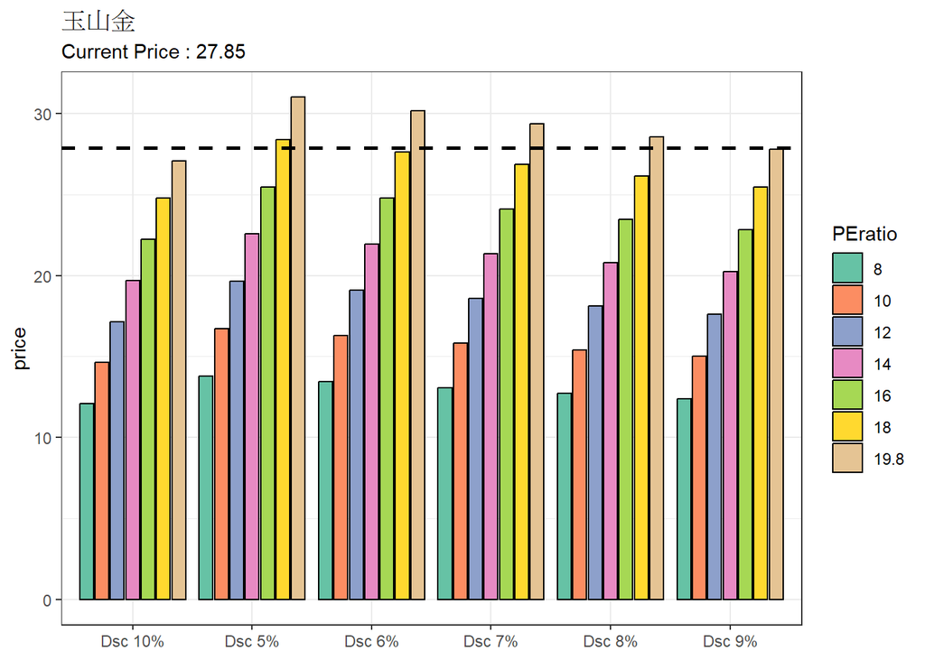

如圖所示，當 PE_ratio 越高預估的股價越高而 Required_rate 越高則預估的股價越低。  
而圖中虛線是輸入的股價(Stock_Price )，用以對應該股價在不同 PE_ratio 中隱含的 Required_rate，或者股價在不同 Required_rate 中隱含的 PE_ratio。  
原本想再寫一個 function 套在 $\rm ROE\_valuation()$ 外面，讓我可以一次對 N 個資產做 ROE 評價法預估股價，但想想現在也沒這個需求， 寫到這差不多了，現在是 2024-09-28 再過不久也要進軍營了XD  
這篇 RMarkdown 主要是想把碩士學到的方法實際記錄下來以免忘記，不然網路上到處都是 DCF，沒有上盈課老師的課應該也不會學到 ROE 評價法了。